# Data Science Capstone Milestone Report - Exploratory Analysis

Hiroto Miyake

March 19, 2016

## 1. Background

This capstone project will focus on applying data science in the area of natural language processing. The task will be to analyze data from a corpus called HC Corpora ([www.corpora.heliohost.org](http://wwww.corpora.heliohost.org/)), then develop a Shiny application that will predict the next word based on inputted word or a phase.

This milestone report describes initial exploratory analysis of the HC Corpora dataset to plan the development of a prediction model and application.

## 2. About the Data Set

The data in zipped file can be downloaded here (548MB).

This data set consists of English, German, French, and Russian languages. For this project, only the English set will be used, and this R script assumes that 3 files, `en_US.blog.txt`, `en_US.news.txt`, `en_US.twitter.txt`, are located in R working directory.

Load required packages:

```r
library(knitr)     # required to use `kable` function
library(tm)        # required to perform text mining analysis
library(RWeka)     # required to perform n-gram tolkenization
library(wordcloud) # required to craete Wordcloud visuals
library(ggplot2)   # required to make standard charts
library(gridExtra) # required to make multiple grid plots using ggplot2
```

Display summary table for the data:

```r
filename.blog    <- paste(getwd(),"/en_US.blogs.txt", sep="")
filename.news    <- paste(getwd(),"/en_US.news.txt", sep="")
filename.twitter <- paste(getwd(),"/en_US.twitter.txt", sep="")

dl.blog    <- readLines(filename.blog, warn=FALSE)
dl.news    <- readLines(filename.news, warn=FALSE)
dl.twitter <- readLines(filename.twitter, warn=FALSE)

words.blog    <- strsplit(dl.blog, " ")
words.news    <- strsplit(dl.news, " ")
words.twitter <- strsplit(dl.twitter, " ")

basic.info <- data.frame(filename  = c(basename(filename.blog),
                                       basename(filename.news),
                                       basename(filename.twitter)),
                         filesize  = c(file.size(filename.blog)/1024/1024,
                                       file.size(filename.news)/1024/1024,
                                       file.size(filename.twitter)/1024/1024),
                         linecount = c(length(dl.blog),
                                       length(dl.news),
                                       length(dl.twitter)),
                         wordcount = c(sum(sapply(words.blog, FUN=length, simplify=TRUE)),
                                       sum(sapply(words.news, FUN=length, simplify=TRUE)),
                                       sum(sapply(words.twitter, FUN=length, simplify=TRUE))))

kable(x=basic.info, col.names=c("Filename", "File Size (MB)", "Line Count", "Word Count"), digits=1)
```

| Filename | File Size (MB) | Line Count | Word Count |
| --- | --- | --- | --- |
| en_US.blogs.txt | 200.4 | 899288 | 37334131 |
| en_US.news.txt | 196.3 | 77259 | 2643969 |
| en_US.twitter.txt | 159.4 | 2360148 | 30373543 |

```r
rm(words.blog, words.news, words.twitter, basic.info) # free up memory usage
```

Since data contents are large, we will process a smaller subset of the data for analysis to keep process time and memory usage within management level.

```r
samplesize <- 10000

set.seed(12345)

dl <- sample(c(dl.blog, dl.news, dl.twitter), size=samplesize, replace=TRUE)
```

## 3. Aggregating and Cleaning Data

`tm` package will be used to aggregate the data into a text corpus, a large structured set of texts.

```r
corpus <- Corpus(VectorSource(dl))
```

Transformations are then applied to clean the data to: * remove numbers * remove punctuations * convert to all lowercase * remove whitespace

```r
corpus <- tm_map(corpus, removeNumbers)
corpus <- tm_map(corpus, removePunctuation)
corpus <- tm_map(corpus, content_transformer(tolower))
corpus <- tm_map(corpus, stripWhitespace)
```

The cleaned corpus will be tokenized to form n-gram models to complete the aggregation process. Here, we will produce 1-gram, 2-gram, and 3-gram.

```r
tokenizer.unigram <- function(x) NGramTokenizer(x, Weka_control(min=1, max=1))
tokenizer.bigram  <- function(x) NGramTokenizer(x, Weka_control(min=2, max=2))
tokenizer.trigram <- function(x) NGramTokenizer(x, Weka_control(min=3, max=3))

tdm.unigram <- TermDocumentMatrix(corpus, control=list(tokenize=tokenizer.unigram))
tdm.bigram  <- TermDocumentMatrix(corpus, control=list(tokenize=tokenizer.bigram))
tdm.trigram <- TermDocumentMatrix(corpus, control=list(tokenize=tokenizer.trigram))

tdm.unigram <- removeSparseTerms(tdm.unigram, sparse=0.99)
tdm.bigram <- removeSparseTerms(tdm.bigram, sparse=0.99)
tdm.trigram <- removeSparseTerms(tdm.trigram, sparse=0.999)
```

## 4. Visualizing Data

### Histogram of top 25 words or phrases

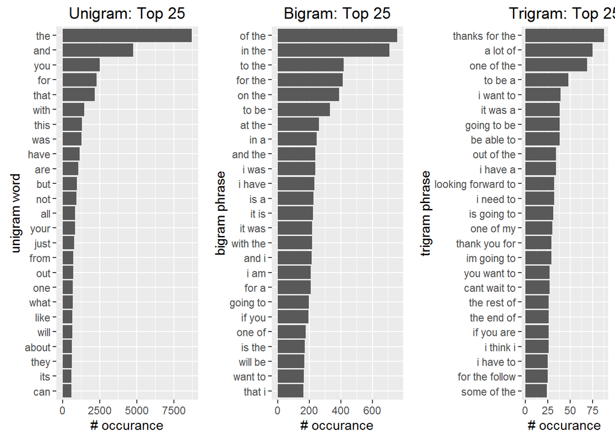

```r
freq.unigram <- sort(rowSums(as.matrix(tdm.unigram)), decreasing=TRUE)
freq.unigram <- data.frame(word=names(freq.unigram), freq=freq.unigram)

freq.bigram <- sort(rowSums(as.matrix(tdm.bigram)), decreasing=TRUE)
freq.bigram <- data.frame(word=names(freq.bigram), freq=freq.bigram)

freq.trigram <- sort(rowSums(as.matrix(tdm.trigram)), decreasing=TRUE)
freq.trigram <- data.frame(word=names(freq.trigram), freq=freq.trigram)

p1 <- ggplot(freq.unigram[1:25,], aes(x=reorder(word, freq), y=freq)) +
             geom_bar(stat="identity") + coord_flip() +
             labs(title="Unigram: Top 25", y="# occurance", x="unigram word")

p2 <- ggplot(freq.bigram[1:25,], aes(x=reorder(word, freq), y=freq)) +
             geom_bar(stat="identity") + coord_flip() +
             labs(title="Bigram: Top 25", y="# occurance", x="bigram phrase")

p3 <- ggplot(freq.trigram[1:25,], aes(x=reorder(word, freq), y=freq)) +
             geom_bar(stat="identity") + coord_flip() +
             labs(title="Trigram: Top 25", y="# occurance", x="trigram phrase")
grid.arrange(p1, p2, p3, ncol=3)
```

### Wordcloud visualization

Below is a Wordcloud visualization of top 50 unigram

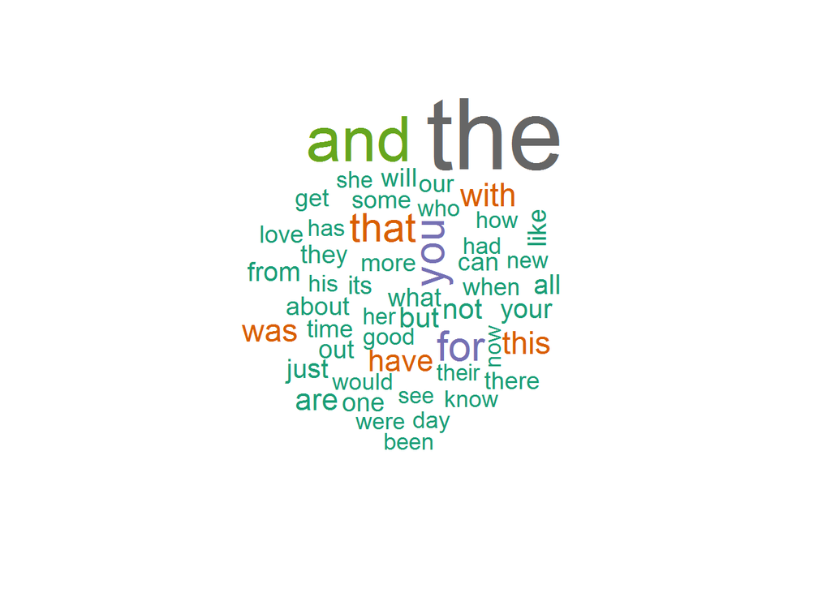

```r
wordcloud(words=freq.unigram$word, freq=freq.unigram$freq, max.words=50, scale=c(5, 1), colors=brewer.pal(8, "Dark2"))
```

Below is a Wordcloud visualization of top 50 bigram

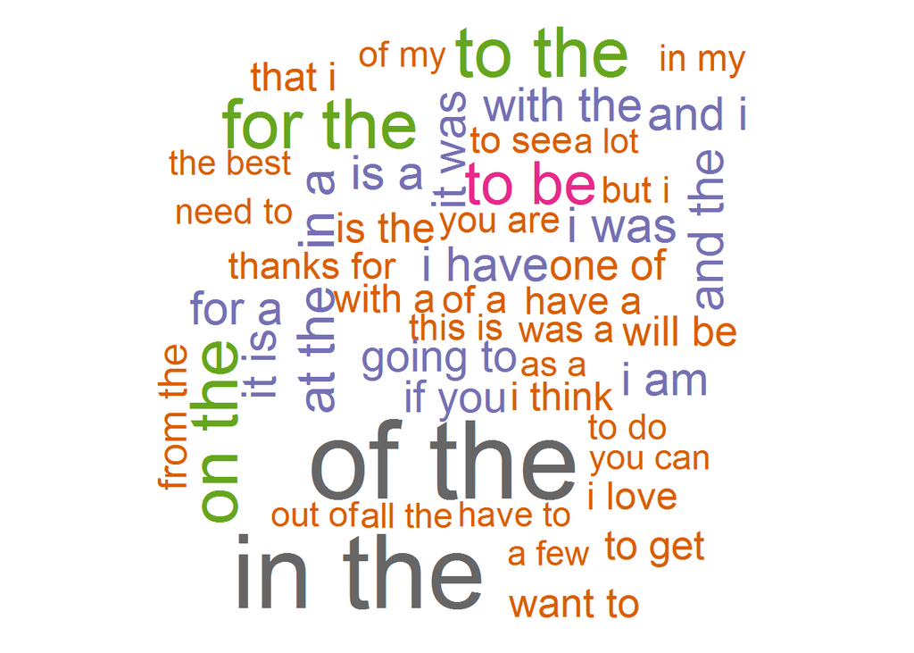

```r
wordcloud(words=freq.bigram$word, freq=freq.bigram$freq, max.word=50, scale=c(5, 1), colors=brewer.pal(8, "Dark2"))
```

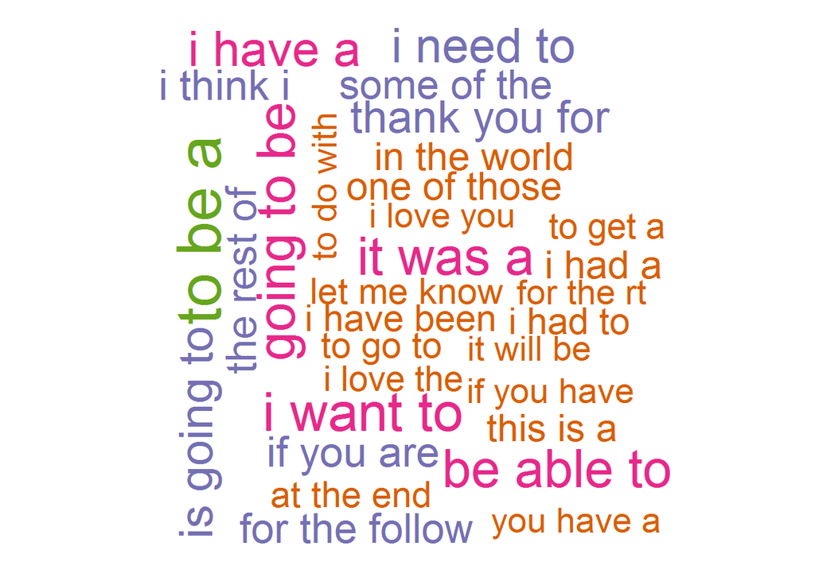

```r
wordcloud(words=freq.trigram$word, freq.trigram$freq, max.word=50, scale=c(5, 1), colors=brewer.pal(8, "Dark2"))
```

## 5. Next Steps

Next step will be to:

1. build a prediction model using the n-gram analysis as demonstrated above,
2. build a data product with front-end user interface in Shiny application framework, and
3. tune the prediction performance to balance between speed and accuracy.